# Problem Set 1:fixed income securities

YUANJIAN ZHOU

Jan 24,2020

- Appreciate Mr. Julian for the instruction of problem 5.

# 1.

## (a)

$$PV_a = \frac{C}{r}(1-\frac{1}{(1+r)^{T}})=\frac{100}{0.03}(1-\frac{1}{(1.03)^{5}})\approx457.9707$$

```r
print(100/0.03*(1-1/(1.03**5)))
```

```
## [1] 457.9707
```

## (b)

$$PV_b = \frac{100}{1.03^6}+\cdots=\frac{C}{r}-\frac{100}{0.03}(1-\frac{1}{(1.03)^{5}})=\frac{100}{0.03}-457.9707\approx2875.363$$

```r
print(100/0.03-457.9707)
```

```
## [1] 2875.363
```

## (c)

$$PV_c = \frac{C}{r}=\frac{100}{0.03} \approx 3333.33$$

```r
print(100/0.03)
```

```
## [1] 3333.333
```

## (d)

Approximately,
$$PV_a + PV_b = PV_c$$

- It is because in (b) we just calculate the price of a perpetuity which does not pay in the first 5 years, and in (a) we calculate the present value for payment in the first years, so the present value in (c) is just the price of the perpetuity.

# 2.

$$\begin{aligned}
1100 &= \sum^{8}_{k=1}\frac{1000*5\%*0.5}{(1+0.5y)^k}+\frac{1000}{(1+0.5y)^8}\\
&=\frac{25}{0.5y}(1-\frac{1}{(1+0.5y)^8})+\frac{1000}{(1+0.5y)^8}\\
y&\approx2.365\%
\end{aligned}$$

# 3.

## (a)

$$PV_L = \frac{1000000}{1.01^{15}}\approx861349.47$$

## (b)

- In order to get immunization, we need to calculate the duration of the portfolio.
  $$D_L * 861149.47 = D_A * A\\
  15 * 861349.47 = D_A * 861349.47\\
  D_A = 15$$
- Then we can calculate the weight of these two bonds.
  $$2 * x + 20 (1-x) = 15\\
  x\approx0.278\\
  A_2 =861349.47 * 0.278 \approx 239455.15\\
  A_{20} = 861349.47 * 0.722 \approx621894.32$$
- We buy **239455.15** 2 year zero coupon bond, **621894.32** 20 year zero coupon bond.

## (c)

$$
$$\begin{align*}
\Delta L_{appro} &= -L * \frac{D_L}{1+y} * \Delta y \\
&= -861349.47 * \frac{15}{1+0.01}*0.0025\\&\approx-31980.8\\
\Delta A_{appro} &= -A * \frac{D_A}{1+y} * \Delta y \\
&= -861349.47 * \frac{15}{1+0.01}*0.0025\\&\approx-31980.8
\end{align*}$$
$$

$$\begin{aligned}
\Delta L_{exact}&= L*\frac{1.01^{15}}{1.0125^{15}} - L\\
&\approx -31356.3\\
\Delta A_{exact} &\approx A_{20}*\frac{1.01^{20}}{1.0125^{20}}-A_{20}+\\
&A_{2}*\frac{1.01^{2}}{1.0125^{2}}-A_{2}\\
&\approx-31182.05
\end{aligned}$$

## (d)

There is no change in liability.

$$\begin{aligned}
\Delta A_{30,appro} &= -A* \frac{D_A}{1+y}*\Delta y\\
&=-A*\frac{30}{1.01}*0.0025\\
&\approx -63961.59\\
\Delta A_{30,exact}&= A_{30}*\frac{1.01^{30}}{1.0125^{30}}-A_{30}\\
&\approx-61571.11\\
\end{aligned}$$

- The difference is because 30 year zero coupon has a longer duration, so it is more sensitive to the change in interest rate.

# 4

## (a)

- It is upward slopping because ceteris paribus, longer time to maturity bond has a larger YTM.

## (b)

- According to expectation hypothesis:

$$(1+r_{0,2})^2 = E[(1+r_{0,1})*(1+r_{1,1})]\\
1.1^2 = 1.08* E[r_{1,1}]\\
E[r_{1,1}] \approx 0.12$$

## (c)

$$[(1.08)(1.06)]^\frac{1}{2} \approx 1.07 < 1+r_{0,2}$$

- So the investor will buy a two year zero coupon bond, for it has a higher annual YTM.

## (d)

- According to the expectation hypothesis, the equilibrium will be broken, and in order to achieve the equilibrium again, $r_{0,2}$ has to decrease. The new $r_{0,2}$ will be:

$$1+r_{0,2} = E[(1+r_{0,1})(1+r_{1,1})]^\frac{1}{2} = (1.08*1.06)^\frac{1}{2}\approx1.07 \\
r_{0,2} \approx 0.07 < r_{0,1}$$

- This time the term structure will be downward slopping, because ceteris paribus, YTM will decrease when time to maturity increases.

# 5.

# (a) (b) (c)

- Details in the excel file.

# (d)

```r
# Load Data
setwd("C:/Users/zyj37/Desktop/MAE/Winter/ECON 433/Homework")
data = read_excel("BondQuotes.xlsx")

# create relevant columns
coupon = as.matrix(data[1:19, 2])
datespayout = as.matrix(t(data[1:59, 8]))
maturity = as.matrix(data[1:19, 6])
accruedinterest = as.matrix(data[1:19, 5] / 182 * coupon / 2)
price_obs = as.matrix((data[1:19, 3] + data[1:19, 4])/2 + accruedinterest)

# function
fn = function(x) {
  # print the parameters
  print(x)

  # get the parameters
  a1 = x[1]
  a2 = x[2]
  a3 = x[3]

  # this is a matrix with the difference btw maturity and dates of payout
  daysmatrix = maturity %*% ones(1,dim(datespayout)[2]) - ones(dim(maturity)[1],1) %*% datespayout


  # time to payout in terms of years
  timetopayout = datespayout / 365

  # compute the discount rate
  discountrate = a1 * timetopayout + a2 * timetopayout^2 + a3 * timetopayout^3

  # price ZCB
  priceZCB =  exp(-discountrate * timetopayout)

  # payment matrix
  daysmatrix[daysmatrix < 0] = NA
  paymentbydaysmatrix = (daysmatrix == 0) * 100 + 0.5 * coupon %*% ones(1, dim(datespayout)[2])
  paymentbydaysmatrix[is.na(paymentbydaysmatrix)] = 0

  # times the price computed with the discount factor, 2 means column-wise
  paymentbydaysmatrix_d = sweep(paymentbydaysmatrix, MARGIN = 2, as.matrix(priceZCB),FUN = "*" )


  # estimated price
  PVestimate = rowSums(paymentbydaysmatrix_d)

  # squared errors
  sqrterrors = (price_obs - PVestimate)^2
  sqrterrors = sum(sqrterrors)

}
```

```r
# upper and lower bounds
bmax1 = 0.01
bmax2 = 0.001
bmax3 = 0.001
ub1 = c(bmax1, bmax2, bmax3)
lb1 = - ub1

# initial values
x0 = c(0.0015, -0.00006, 0.0000009)
solnp_result = solnp(x0, fn, LB = lb1, UB = ub1)
```

```
## [1]  1.5e-03 -6.0e-05  9.0e-07
## [1]  1.5e-03 -6.0e-05  9.0e-07
## [1]  0.0015001 -0.0000600  0.0000009
## [1]  1.50e-03 -5.99e-05  9.00e-07
## [1]  1.5e-03 -6.0e-05  1.0e-06
## [1]  1.593731e-03 -3.423069e-05  6.282498e-04
## [1]  1.546865e-03 -4.711534e-05  3.145749e-04
## [1]  1.523433e-03 -5.355767e-05  1.577375e-04
## [1]  1.511716e-03 -5.677884e-05  7.931873e-05
## [1]  1.505858e-03 -5.838942e-05  4.010937e-05
## [1]  1.502929e-03 -5.919471e-05  2.050468e-05
## [1]  1.501465e-03 -5.959735e-05  1.070234e-05
## [1]  1.500732e-03 -5.979868e-05  5.801171e-06
## [1]  1.500366e-03 -5.989934e-05  3.350585e-06
## [1]  1.500183e-03 -5.994967e-05  2.125293e-06
```

[output cut: 105 more lines]

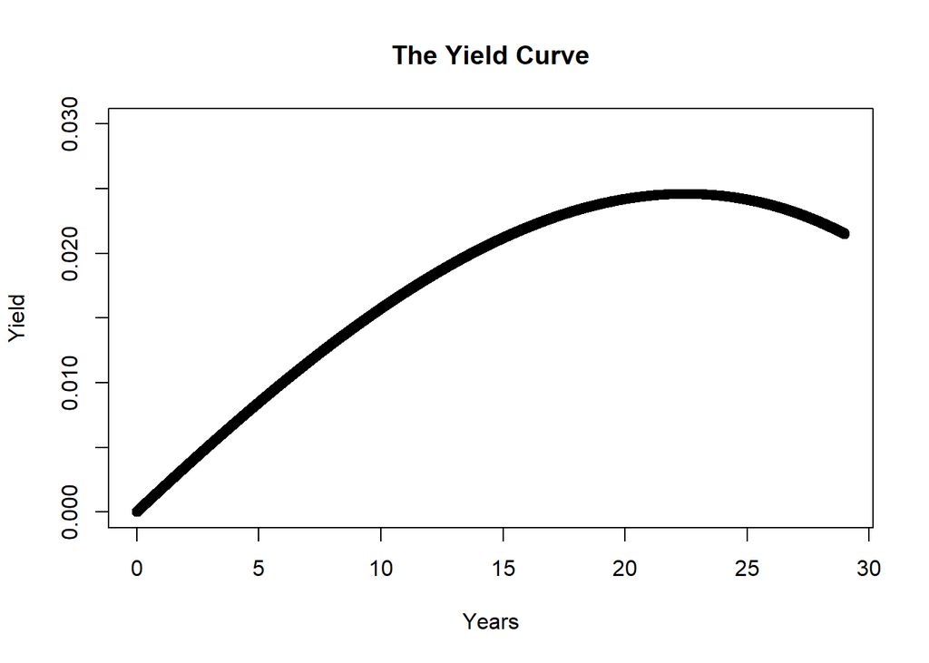

```r
# plot
p1 = solnp_result[["pars"]][1]
p2 = solnp_result[["pars"]][2]
p3 = solnp_result[["pars"]][3]

t = seq(0, 29, 0.001)
plot(t, p1 * t + p2 * t^2 + p3 * t^3,
    main = "The Yield Curve",
    ylab = "Yield", xlab = "Years", xlim = c(0, 29),
    ylim = c(0, 0.03))
```